# Contagious Yawning in Dogs: Prosocial Experiment Analysis (Part 2)

Scott Claessens and Patrick Neilands

2020-01-09

The purpose of this document is to analyse data from a new experiment on contagious yawning in dogs in the presence of either a prosocial or antisocial demonstrator.

# 0. Setup

Load the data.

```r
d <-
  read.csv("data/yawnProsocial.csv") %>%
  as_tibble() %>%
  # create dummy variables for analysis
  mutate(condition = ifelse(condition == "Anti-Social", 0, 1),
         trial     = ifelse(trial == 1, 0, 1))

d
```

| ID | condition | numberYawns | trial | secs |
| --- | --- | --- | --- | --- |
| Axl | 1 | 0 | 1 | 300 |
| Smith | 1 | 0 | 1 | 300 |
| Dice | 1 | 0 | 0 | 300 |
| Tweed | 1 | 0 | 1 | 300 |
| Plum | 1 | 0 | 0 | 300 |
| Jack | 1 | 0 | 0 | 300 |
| Kohi | 1 | 0 | 1 | 300 |
| Manny | 1 | 0 | 1 | 300 |
| Meg | 1 | 1 | 0 | 300 |
| Ruby | 1 | 1 | 0 | 300 |

[output cut: 54 more lines]

In the previous document (`yawnProsocial.rmd`), we analysed these data using zero-inflated Poisson models. Following the suggestions of two reviewers, we now re-analyse these data using hurdle Poisson models.

# 1. Fit hurdle Poisson models

## 1.1. Intercept-only model

We fitted this model in the previous document.

```
##  Family: hurdle_poisson
##   Links: mu = log; hu = logit
## Formula: numberYawns ~ 0 + intercept + offset(log(secs)) + (0 + intercept | ID)
##          hu ~ 0 + intercept + (0 + intercept | ID)
##    Data: d (Number of observations: 64)
## Samples: 4 chains, each with iter = 2000; warmup = 1000; thin = 1;
##          total post-warmup samples = 4000
##
## Group-Level Effects:
## ~ID (Number of levels: 32)
##                  Estimate Est.Error l-95% CI u-95% CI Rhat Bulk_ESS Tail_ESS
## sd(intercept)        0.38      0.30     0.02     1.11 1.00     1622     2356
## sd(hu_intercept)     0.70      0.53     0.03     1.95 1.00     1080     2208
##
## Population-Level Effects:
##              Estimate Est.Error l-95% CI u-95% CI Rhat Bulk_ESS Tail_ESS
## intercept       -5.87      0.27    -6.47    -5.40 1.00     3248     2187
## hu_intercept    -0.28      0.30    -0.88     0.27 1.00     3868     2475
##
## Samples were drawn using sampling(NUTS). For each parameter, Eff.Sample
## is a crude measure of effective sample size, and Rhat is the potential
## scale reduction factor on split chains (at convergence, Rhat = 1).
```

What priors did we use?

| prior | class | coef | group | resp | dpar | nlpar | bound |
| --- | --- | --- | --- | --- | --- | --- | --- |
|  | b |  |  |  |  |  |  |
| student_t(3, -2, 10) | b | intercept |  |  |  |  |  |
|  | b |  |  |  | hu |  |  |
| logistic(0, 1) | b | intercept |  |  | hu |  |  |
| student_t(3, 0, 10) | sd |  |  |  |  |  |  |
| student_t(3, 0, 0.5) | sd |  |  |  | hu |  |  |
|  | sd |  | ID |  |  |  |  |
|  | sd | intercept | ID |  |  |  |  |
|  | sd |  | ID |  | hu |  |  |
|  | sd | intercept | ID |  | hu |  |  |

Let’s interpret each parameter in turn. The hurdle parameter `hu` is -0.28. This is on the logit scale, so we need to calculate the inverse logit.

```r
post <- posterior_samples(m9.1)

1 - inv_logit_scaled(post$b_hu_intercept) %>% # prob of yawning
  median() %>%
  round(2)
```

```
## [1] 0.57
```

Let’s calculate the average yawning rate.

```r
(exp(post$b_intercept) * 60) %>% # Yawning rate (per min)
  median() %>%
  round(2)
```

```
## [1] 0.17
```

The dogs yawn 0.17 times a minute, on average.

## 1.2. Condition-only model

We also fitted this model in the previous document.

```
##  Family: hurdle_poisson
##   Links: mu = log; hu = logit
## Formula: numberYawns ~ 0 + intercept + condition + offset(log(secs)) + (0 + intercept + condition | ID)
##          hu ~ 0 + intercept + condition + (0 + intercept + condition | ID)
##    Data: d (Number of observations: 64)
## Samples: 4 chains, each with iter = 2000; warmup = 1000; thin = 1;
##          total post-warmup samples = 4000
##
## Group-Level Effects:
## ~ID (Number of levels: 32)
##                                Estimate Est.Error l-95% CI u-95% CI Rhat Bulk_ESS Tail_ESS
## sd(intercept)                      0.42      0.34     0.01     1.29 1.00     1018     1353
## sd(condition)                      0.87      0.69     0.03     2.54 1.00      960     1234
## sd(hu_intercept)                   0.72      0.58     0.03     2.14 1.00      949     1279
## sd(hu_condition)                   0.60      0.76     0.02     2.43 1.00     1363     1837
## cor(intercept,condition)          -0.16      0.56    -0.97     0.92 1.00     1722     2278
## cor(hu_intercept,hu_condition)     0.08      0.57    -0.94     0.96 1.00     2389     1990
##
## Population-Level Effects:
##              Estimate Est.Error l-95% CI u-95% CI Rhat Bulk_ESS Tail_ESS
## intercept       -5.78      0.34    -6.54    -5.20 1.00     2488     1788
## condition       -0.59      0.54    -1.75     0.40 1.00     2718     2207
## hu_intercept    -0.38      0.39    -1.19     0.34 1.00     2879     2533
## hu_condition     0.18      0.49    -0.80     1.18 1.00     3437     3102
##
## Samples were drawn using sampling(NUTS). For each parameter, Eff.Sample
## is a crude measure of effective sample size, and Rhat is the potential
## scale reduction factor on split chains (at convergence, Rhat = 1).
```

What priors did we use?

| prior | class | coef | group | resp | dpar | nlpar | bound |
| --- | --- | --- | --- | --- | --- | --- | --- |
|  | b |  |  |  |  |  |  |
| normal(0, 1) | b | condition |  |  |  |  |  |
| student_t(3, -2, 10) | b | intercept |  |  |  |  |  |
|  | b |  |  |  | hu |  |  |
| normal(0, 1) | b | condition |  |  | hu |  |  |
| logistic(0, 1) | b | intercept |  |  | hu |  |  |
| lkj_corr_cholesky(1) | L |  |  |  |  |  |  |
|  | L |  | ID |  |  |  |  |
| student_t(3, 0, 10) | sd |  |  |  |  |  |  |
| student_t(3, 0, 0.5) | sd |  |  |  | hu |  |  |

[output cut: 6 more lines]

The condition parameters have 95% CIs crossing zero, suggesting that there is no difference in probability of yawning or yawning rates between conditions. Let’s calculate this directly.

```r
post <- posterior_samples(m9.2)

# prob yawning in Anti-Social condition
(1 - inv_logit_scaled(post$b_hu_intercept)) %>%
  median() %>%
  round(2)
```

```
## [1] 0.59
```

```r
# prob yawning in Pro-Social condition
(1 - inv_logit_scaled(post$b_hu_intercept + post$b_hu_condition)) %>%
  median() %>%
  round(2)
```

```
## [1] 0.55
```

No difference between these probabilities.

```r
(sum(post$b_hu_condition > 0) / length(post$b_hu_condition)) %>% round(2)
```

```
## [1] 0.65
```

```r
# Yawning rate (per min) in Anti-Social condition
(exp(post$b_intercept) * 60) %>%
  median() %>%
  round(2)
```

```
## [1] 0.19
```

```r
# Yawning rate (per min) in Pro-Social condition
(exp(post$b_intercept + post$b_condition) * 60) %>%
  median() %>%
  round(2)
```

```
## [1] 0.11
```

Psoterior probability mass shows that the difference between these is not substantial.

```r
(sum(post$b_condition < 0) / length(post$b_condition)) %>% round(2)
```

```
## [1] 0.88
```

Let’s visualise these diferences on the original scales.

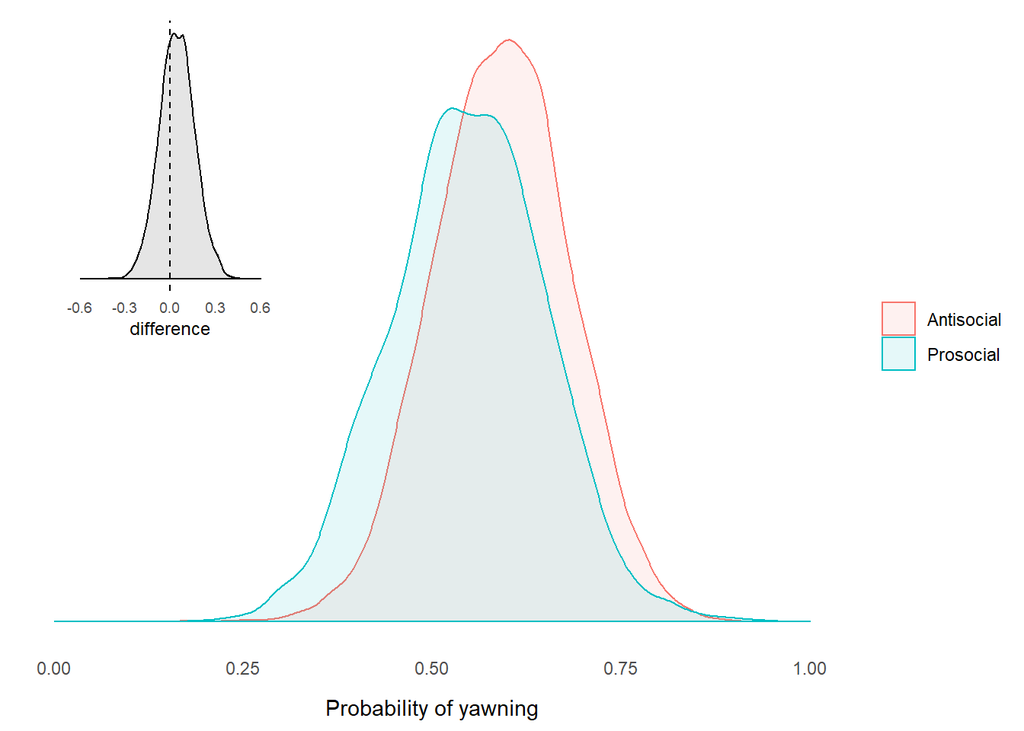

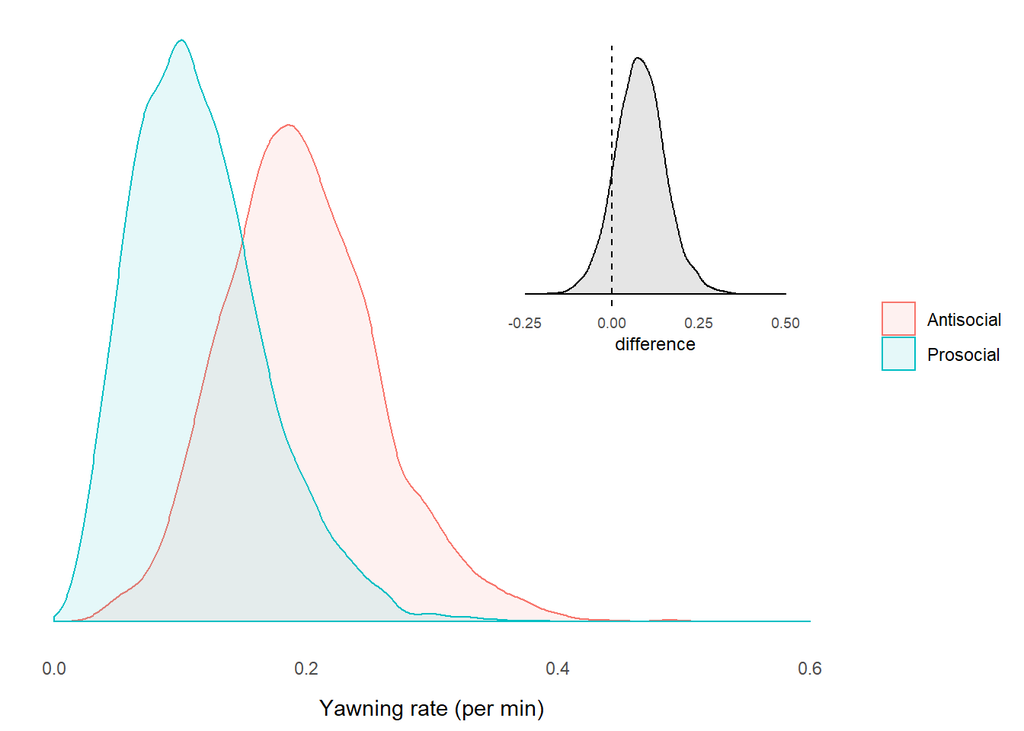

## 1.3. Trial-only model

```
##  Family: hurdle_poisson
##   Links: mu = log; hu = logit
## Formula: numberYawns ~ 0 + intercept + trial + offset(log(secs)) + (0 + intercept + trial | ID)
##          hu ~ 0 + intercept + trial + (0 + intercept + trial | ID)
##    Data: d (Number of observations: 64)
## Samples: 4 chains, each with iter = 2000; warmup = 1000; thin = 1;
##          total post-warmup samples = 4000
##
## Group-Level Effects:
## ~ID (Number of levels: 32)
##                            Estimate Est.Error l-95% CI u-95% CI Rhat Bulk_ESS Tail_ESS
## sd(intercept)                  0.42      0.35     0.01     1.32 1.00     1513     1666
## sd(trial)                      0.97      0.78     0.04     2.88 1.00     1108     1224
## sd(hu_intercept)               0.76      0.58     0.03     2.16 1.00     1076     1845
## sd(hu_trial)                   0.66      1.09     0.02     2.78 1.00     1439     1729
## cor(intercept,trial)          -0.14      0.56    -0.97     0.92 1.00     1719     2172
## cor(hu_intercept,hu_trial)     0.10      0.57    -0.93     0.95 1.00     3717     2705
##
## Population-Level Effects:
##              Estimate Est.Error l-95% CI u-95% CI Rhat Bulk_ESS Tail_ESS
## intercept       -5.88      0.35    -6.64    -5.29 1.00     3595     2380
## trial           -0.41      0.56    -1.63     0.61 1.00     2675     2539
## hu_intercept    -0.50      0.39    -1.31     0.23 1.00     3421     2952
## hu_trial         0.42      0.50    -0.56     1.40 1.00     3473     2953
##
## Samples were drawn using sampling(NUTS). For each parameter, Eff.Sample
## is a crude measure of effective sample size, and Rhat is the potential
## scale reduction factor on split chains (at convergence, Rhat = 1).
```

Priors.

| prior | class | coef | group | resp | dpar | nlpar | bound |
| --- | --- | --- | --- | --- | --- | --- | --- |
|  | b |  |  |  |  |  |  |
| student_t(3, -2, 10) | b | intercept |  |  |  |  |  |
| normal(0, 1) | b | trial |  |  |  |  |  |
|  | b |  |  |  | hu |  |  |
| logistic(0, 1) | b | intercept |  |  | hu |  |  |
| normal(0, 1) | b | trial |  |  | hu |  |  |
| lkj_corr_cholesky(1) | L |  |  |  |  |  |  |
|  | L |  | ID |  |  |  |  |
| student_t(3, 0, 10) | sd |  |  |  |  |  |  |
| student_t(3, 0, 0.5) | sd |  |  |  | hu |  |  |

[output cut: 6 more lines]

## 1.4. Condition + Trial model

```
##  Family: hurdle_poisson
##   Links: mu = log; hu = logit
## Formula: numberYawns ~ 0 + intercept + condition + trial + offset(log(secs)) + (0 + intercept + condition + trial | ID)
##          hu ~ 0 + intercept + condition + trial + (0 + intercept + condition + trial | ID)
##    Data: d (Number of observations: 64)
## Samples: 4 chains, each with iter = 2000; warmup = 1000; thin = 1;
##          total post-warmup samples = 4000
##
## Group-Level Effects:
## ~ID (Number of levels: 32)
##                                Estimate Est.Error l-95% CI u-95% CI Rhat Bulk_ESS Tail_ESS
## sd(intercept)                      0.49      0.41     0.02     1.51 1.00     1379     1574
## sd(condition)                      0.87      0.74     0.03     2.74 1.00     1245     1641
## sd(trial)                          0.96      0.78     0.05     2.93 1.00     1249     2250
## sd(hu_intercept)                   0.73      0.59     0.03     2.16 1.00     1170     1698
## sd(hu_condition)                   0.58      0.75     0.02     2.27 1.00     1846     1775
## sd(hu_trial)                       0.63      0.87     0.02     2.58 1.00     1742     2235
## cor(intercept,condition)          -0.11      0.51    -0.90     0.88 1.00     2490     2391
## cor(intercept,trial)              -0.12      0.50    -0.91     0.84 1.00     2542     2530
## cor(condition,trial)               0.01      0.50    -0.88     0.88 1.00     2042     2801
## cor(hu_intercept,hu_condition)     0.03      0.51    -0.87     0.90 1.00     3921     2853
## cor(hu_intercept,hu_trial)         0.06      0.49    -0.85     0.89 1.00     3192     2867
## cor(hu_condition,hu_trial)         0.02      0.51    -0.89     0.87 1.00     3122     2830
##
## Population-Level Effects:
##              Estimate Est.Error l-95% CI u-95% CI Rhat Bulk_ESS Tail_ESS
## intercept       -5.79      0.42    -6.76    -5.09 1.00     2444     2249
## condition       -0.56      0.57    -1.76     0.51 1.00     3505     2573
## trial           -0.39      0.55    -1.57     0.66 1.00     2837     2893
## hu_intercept    -0.56      0.44    -1.46     0.28 1.00     4033     2928
## hu_condition     0.15      0.50    -0.83     1.12 1.00     4563     3276
## hu_trial         0.39      0.52    -0.64     1.41 1.00     4893     2698
##
## Samples were drawn using sampling(NUTS). For each parameter, Eff.Sample
## is a crude measure of effective sample size, and Rhat is the potential
## scale reduction factor on split chains (at convergence, Rhat = 1).
```

Priors.

| prior | class | coef | group | resp | dpar | nlpar | bound |
| --- | --- | --- | --- | --- | --- | --- | --- |
|  | b |  |  |  |  |  |  |
| normal(0, 1) | b | condition |  |  |  |  |  |
| student_t(3, -2, 10) | b | intercept |  |  |  |  |  |
| normal(0, 1) | b | trial |  |  |  |  |  |
|  | b |  |  |  | hu |  |  |
| normal(0, 1) | b | condition |  |  | hu |  |  |
| logistic(0, 1) | b | intercept |  |  | hu |  |  |
| normal(0, 1) | b | trial |  |  | hu |  |  |
| lkj_corr_cholesky(1) | L |  |  |  |  |  |  |
|  | L |  | ID |  |  |  |  |

[output cut: 10 more lines]

## 1.5. Interaction model

```
##  Family: hurdle_poisson
##   Links: mu = log; hu = logit
## Formula: numberYawns ~ 0 + intercept + condition + trial + condition:trial + offset(log(secs)) + (0 + intercept + condition + trial + condition:trial | ID)
##          hu ~ 0 + intercept + condition + trial + condition:trial + (0 + intercept + condition + trial + condition:trial | ID)
##    Data: d (Number of observations: 64)
## Samples: 4 chains, each with iter = 2000; warmup = 1000; thin = 1;
##          total post-warmup samples = 4000
##
## Group-Level Effects:
## ~ID (Number of levels: 32)
##                                      Estimate Est.Error l-95% CI u-95% CI Rhat Bulk_ESS Tail_ESS
## sd(intercept)                            0.43      0.34     0.02     1.28 1.00     1670     2092
## sd(condition)                            0.76      0.59     0.03     2.23 1.00     1746     2152
## sd(trial)                                0.79      0.62     0.03     2.28 1.00     1755     2031
## sd(condition:trial)                      1.43      1.27     0.05     4.57 1.00     2450     1790
## sd(hu_intercept)                         0.83      0.65     0.03     2.42 1.00     1074     1627
## sd(hu_condition)                         0.60      0.74     0.02     2.37 1.00     1743     2188
## sd(hu_trial)                             0.61      0.77     0.02     2.38 1.00     1937     2146
## sd(hu_condition:trial)                   0.59      0.70     0.01     2.40 1.00     2507     1949
## cor(intercept,condition)                -0.08      0.45    -0.84     0.78 1.00     3514     3161
## cor(intercept,trial)                    -0.07      0.45    -0.83     0.79 1.00     3406     3275
## cor(condition,trial)                     0.01      0.45    -0.79     0.82 1.00     3482     3268
## cor(intercept,condition:trial)          -0.04      0.44    -0.82     0.77 1.00     3887     3013
## cor(condition,condition:trial)           0.00      0.45    -0.82     0.82 1.00     4069     3196
## cor(trial,condition:trial)              -0.03      0.45    -0.83     0.79 1.00     3749     3529
## cor(hu_intercept,hu_condition)           0.04      0.44    -0.77     0.82 1.00     4546     2930
## cor(hu_intercept,hu_trial)               0.05      0.45    -0.80     0.83 1.00     5039     2554
## cor(hu_condition,hu_trial)               0.03      0.45    -0.78     0.82 1.00     3521     3296
## cor(hu_intercept,hu_condition:trial)     0.02      0.46    -0.82     0.83 1.00     5981     2889
## cor(hu_condition,hu_condition:trial)    -0.00      0.45    -0.82     0.82 1.00     3947     3055
## cor(hu_trial,hu_condition:trial)         0.01      0.45    -0.82     0.81 1.00     3399     3370
##
## Population-Level Effects:
##                    Estimate Est.Error l-95% CI u-95% CI Rhat Bulk_ESS Tail_ESS
## intercept             -5.77      0.39    -6.66    -5.10 1.00     2932     2081
## condition             -0.51      0.57    -1.71     0.54 1.00     3647     2749
## trial                 -0.32      0.56    -1.52     0.71 1.00     3805     3305
## condition:trial       -0.53      0.82    -2.12     1.00 1.00     5268     3416
## hu_intercept          -0.52      0.47    -1.45     0.37 1.00     3654     3011
## hu_condition          -0.06      0.57    -1.19     1.05 1.00     3992     3142
## hu_trial               0.21      0.57    -0.92     1.31 1.00     3910     3061
## hu_condition:trial     0.56      0.74    -0.92     1.99 1.00     4341     3281
##
## Samples were drawn using sampling(NUTS). For each parameter, Eff.Sample
## is a crude measure of effective sample size, and Rhat is the potential
## scale reduction factor on split chains (at convergence, Rhat = 1).
```

What priors did we use?

| prior | class | coef | group | resp | dpar | nlpar | bound |
| --- | --- | --- | --- | --- | --- | --- | --- |
|  | b |  |  |  |  |  |  |
| normal(0, 1) | b | condition |  |  |  |  |  |
| normal(0, 1) | b | condition:trial |  |  |  |  |  |
| student_t(3, -2, 10) | b | intercept |  |  |  |  |  |
| normal(0, 1) | b | trial |  |  |  |  |  |
|  | b |  |  |  | hu |  |  |
| normal(0, 1) | b | condition |  |  | hu |  |  |
| normal(0, 1) | b | condition:trial |  |  | hu |  |  |
| logistic(0, 1) | b | intercept |  |  | hu |  |  |
| normal(0, 1) | b | trial |  |  | hu |  |  |

[output cut: 14 more lines]

Are there any differences between cells in the 2x2 design? Start with probability.

```r
post <- posterior_samples(m9.5)

# prob yawning
anti1prob <- 1 - inv_logit_scaled(post$b_hu_intercept)
anti2prob <- 1 - inv_logit_scaled(post$b_hu_intercept + post$b_hu_trial)
pro1prob  <- 1 - inv_logit_scaled(post$b_hu_intercept + post$b_hu_condition)
pro2prob  <- 1 - inv_logit_scaled(post$b_hu_intercept + post$b_hu_condition + post$b_hu_trial + post$`b_hu_condition:trial`)

# differences
diff1 <- anti1prob - anti2prob
diff2 <- anti1prob - pro1prob
diff3 <- anti1prob - pro2prob
diff4 <- anti2prob - pro1prob
diff5 <- anti2prob - pro2prob
diff6 <- pro1prob  - pro2prob

(sum(diff1 < 0) / length(diff1)) %>% round(2)
```

```
## [1] 0.35
```

```r
(sum(diff2 < 0) / length(diff2)) %>% round(2)
```

```
## [1] 0.54
```

```r
(sum(diff3 < 0) / length(diff3)) %>% round(2)
```

```
## [1] 0.17
```

```r
(sum(diff4 < 0) / length(diff4)) %>% round(2)
```

```
## [1] 0.64
```

```r
(sum(diff5 < 0) / length(diff5)) %>% round(2)
```

```
## [1] 0.24
```

```r
(sum(diff6 < 0) / length(diff6)) %>% round(2)
```

```
## [1] 0.14
```

```r
# interaction
(sum(diff2 - diff5 < 0) / length(diff2)) %>% round(2)
```

```
## [1] 0.78
```

No differences between cells or interaction effect.

```r
# Yawning rate (per min)
anti1rate <- exp(post$b_intercept) * 60
anti2rate <- exp(post$b_intercept + post$b_trial) * 60
pro1rate  <- exp(post$b_intercept + post$b_condition) * 60
pro2rate  <- exp(post$b_intercept + post$b_condition + post$b_trial + post$`b_condition:trial`) * 60

# differences
diff1 <- anti1rate - anti2rate
diff2 <- anti1rate - pro1rate
diff3 <- anti1rate - pro2rate
diff4 <- anti2rate - pro1rate
diff5 <- anti2rate - pro2rate
diff6 <- pro1rate  - pro2rate

(sum(diff1 > 0) / length(diff1)) %>% round(2)
```

```
## [1] 0.71
```

```r
(sum(diff2 > 0) / length(diff2)) %>% round(2)
```

```
## [1] 0.82
```

```r
(sum(diff3 > 0) / length(diff3)) %>% round(2)
```

```
## [1] 0.92
```

```r
(sum(diff4 > 0) / length(diff4)) %>% round(2)
```

```
## [1] 0.61
```

```r
(sum(diff5 > 0) / length(diff5)) %>% round(2)
```

```
## [1] 0.89
```

```r
(sum(diff6 > 0) / length(diff6)) %>% round(2)
```

```
## [1] 0.83
```

```r
# interaction
(sum(diff2 - diff5 < 0) / length(diff2)) %>% round(2)
```

```
## [1] 0.55
```

No substantial differences between cells or interaction effect.

## 1.6. Compare models

```r
loo_compare(m9.1, m9.2, m9.3, m9.4, m9.5)
```

```
##      elpd_diff se_diff
## m9.1  0.0       0.0
## m9.3 -0.8       1.2
## m9.2 -1.5       1.2
## m9.5 -2.1       1.6
## m9.4 -2.6       1.5
```

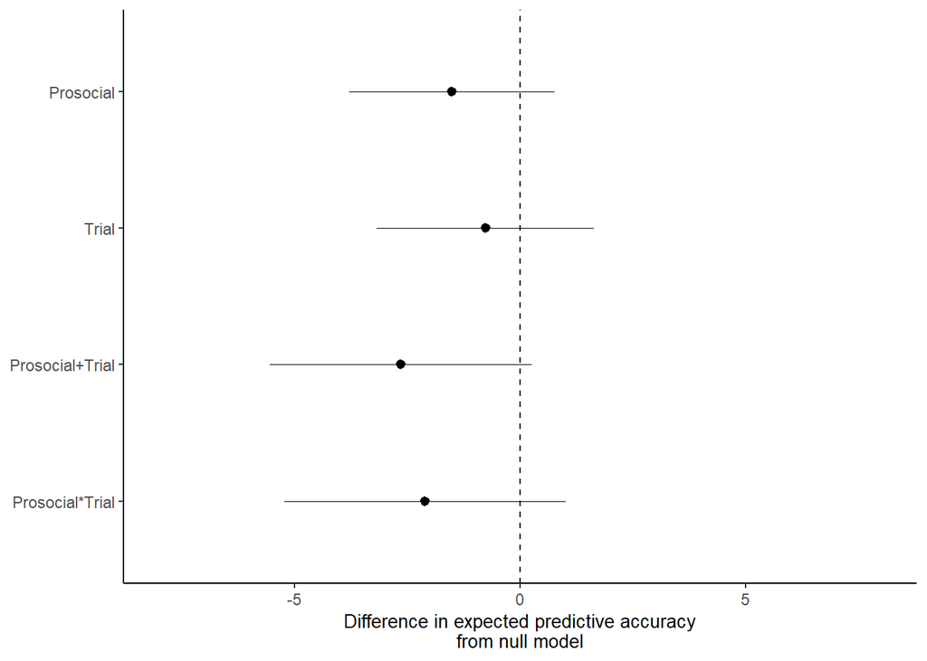